# Suni’s Weekly FDA Analysis Check-in Progress – Pupil Light Reflex

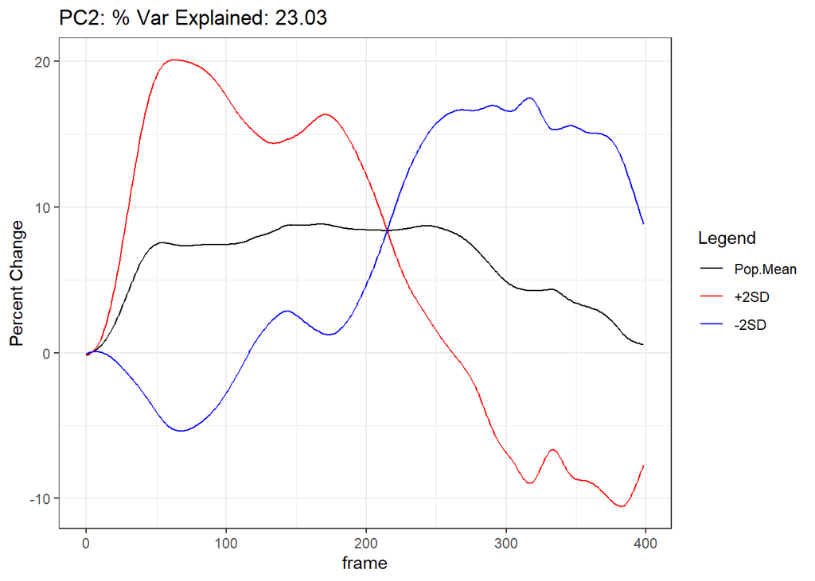

```r
wi.plot_pc2
```

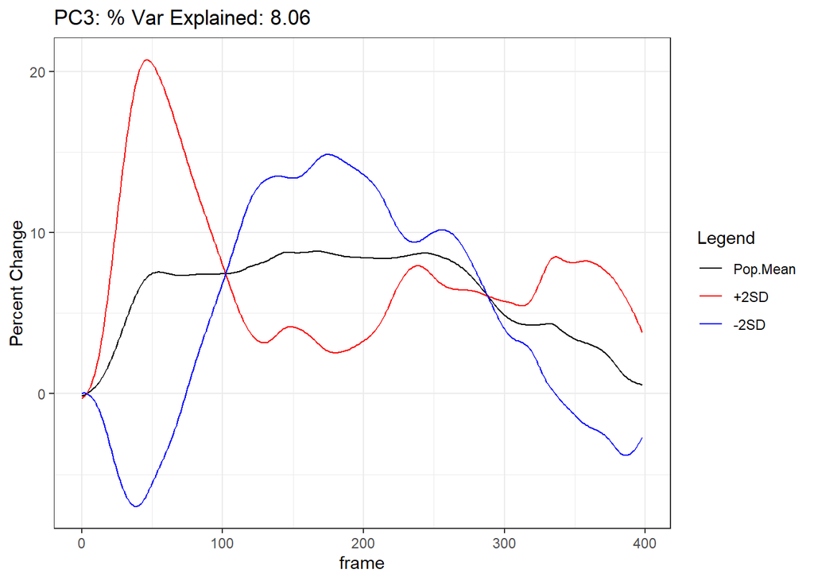

```r
wi.plot_pc3
```

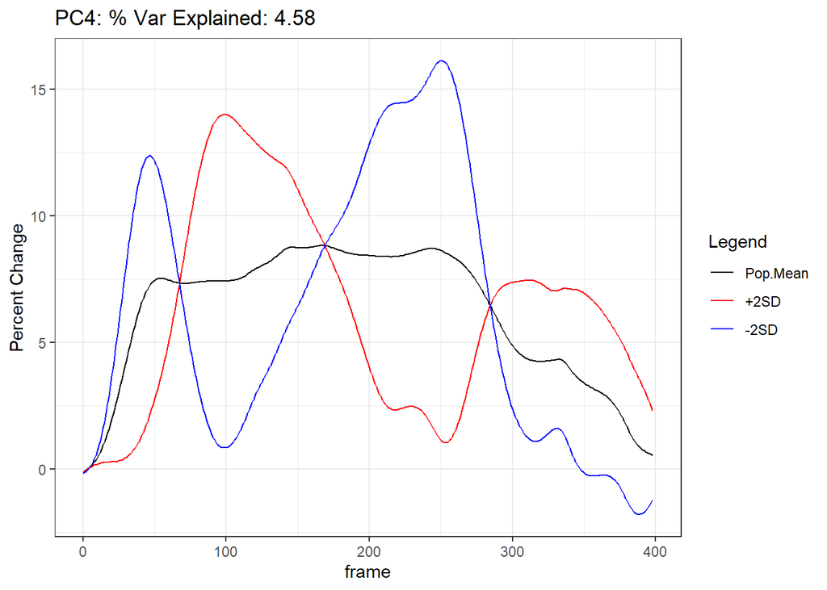

```r
wi.plot_pc4
```

### 7.4.1 Within person difference PC explanations

PC1: Individuals with high loading on PC1 have a large positive within person difference (post-pre) in percent change indicating a weaker constriction at post compared to pre at the beginning of the test. I’m not sure if there is a faster return to baseline or if since the initial constriction is smaller the recovery values are higher. Individual with low loading on PC1 have a negative within person difference (post-pre) in percent change indicating a stronger constriction at post compared to pre.

PC3: Individuals with high loading on PC3 have a weaker initial constriction at post, less change in the dilation after maximal constriction (no noticeable rebound recovery?) Individuals with low loading on PC3 have a stronger initial constriction at post, more change in the dilation after maximal constriction with less dilation in post.

# 8 Meeting 20220908

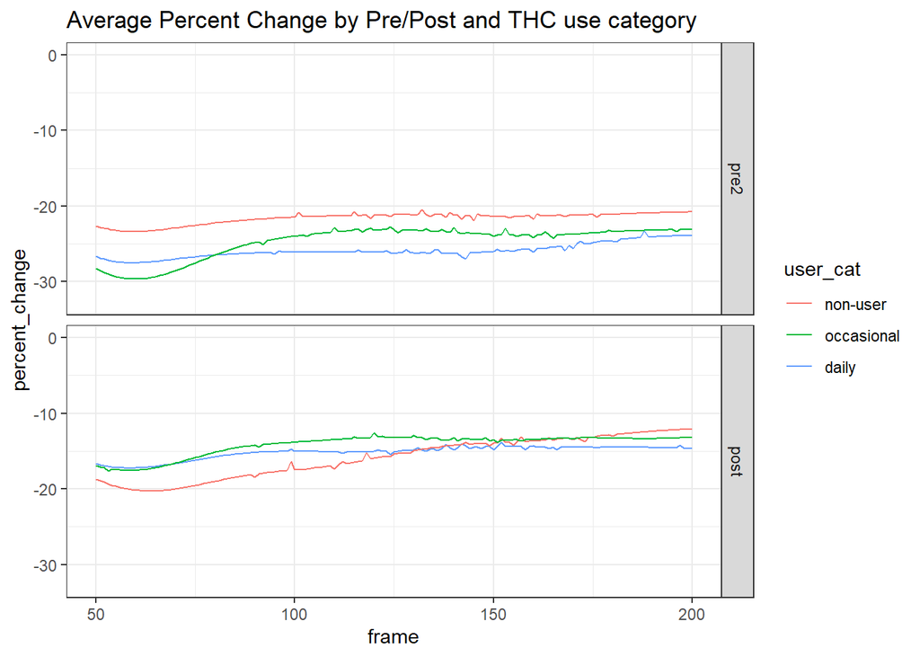

```r
### INVESTIGATE BUMPS IN MEAN Function

## Pre/Post Across subjects
ggplot(mean_fxn.l, aes(x=frame, y = percent_change, group = grp,
                       color = user_cat))+
  geom_line()+
  xlim(50, 200)+
  facet_grid(rows = vars(tp))+
  labs(title = "Average Percent Change by Pre/Post and THC use category")+
  theme_bw()
```

```r
right_0.w[right_0.w$user_cat == "non-user" & right_0.w$tp == "pre2", 103:105]
```

```
##              percent_change.100 percent_change.101 percent_change.102
## 001-003_pre2         -39.841378                 NA         -40.056700
## 001-004_pre2         -20.509286         -20.636732         -20.765188
## 001-007_pre2         -29.728903         -30.372171         -30.985599
## 001-009_pre2         -12.595393         -12.384864         -12.173821
## 001-015_pre2         -27.419396         -27.277259         -27.112306
## 001-029_pre2         -22.422026         -22.324030         -22.238468
## 001-030_pre2         -19.904482         -19.730264         -19.562660
## 001-031_pre2         -26.659914         -26.707617         -26.723738
## 001-032_pre2         -25.607501         -25.790114         -25.972873
## 001-037_pre2         -10.766774         -10.595359         -10.422002
## 001-038_pre2         -14.582329         -14.220651         -13.880713
## 001-039_pre2          -8.698690          -8.442030          -8.215627
## 001-040_pre2         -13.961272         -13.965766         -13.969542
## 001-041_pre2         -22.801896         -23.144297         -23.480081
## 001-042_pre2         -22.334268         -22.256735         -22.200964
## 001-043_pre2         -11.625394         -11.267720         -10.929376
## 001-045_pre2         -24.484764         -23.910475         -23.359554
## 001-046_pre2         -39.228644         -39.117800         -39.005777
## 001-047_pre2          -8.537555          -8.481596          -8.428778
## 001-049_pre2         -20.116576         -19.984262         -19.863703
## 001-050_pre2         -29.870190         -29.993167         -30.145066
## 001-053_pre2         -31.777050         -31.811150         -31.839822
## 001-054_pre2         -19.003078         -18.907631         -18.830007
## 001-055_pre2         -22.701872         -23.326338         -23.938734
## 001-062_pre2          -5.394998          -5.303947          -5.217166
## 001-076_pre2         -43.094073         -42.798501         -42.471884
## 001-077_pre2          -9.357431          -9.313066          -9.234195
## 001-097_pre2          -9.338060          -9.588896          -9.851689
## 001-099_pre2         -32.517179         -32.697862         -32.884544
## 001-095_pre2         -18.898660         -18.708524         -18.520319
```

```r
right_0.w[right_0.w$user_cat == "non-user" & right_0.w$tp == "post", 101:103]
```

```
##              percent_change.98 percent_change.99 percent_change.100
## 001-003_post      -27.75305639      -27.91326406      -28.065082389
## 001-005_post      -21.01370912      -20.83253880      -20.645492261
## 001-007_post      -18.73841901      -18.44515774      -18.149872540
## 001-009_post      -15.26827190      -15.43116451      -15.637138937
## 001-015_post      -23.67193793      -23.55879221      -23.444027674
## 001-029_post      -15.33440459      -15.25812121      -15.180255418
## 001-031_post      -32.88425743      -32.66142950      -32.418305078
## 001-032_post      -17.52611844      -17.36964383      -17.229584914
## 001-037_post       -7.29583958       -7.30140515       -7.306222361
## 001-038_post      -14.32806070      -14.11913282      -13.920713830
## 001-039_post       -6.30042900       -6.35728727       -6.401904783
## 001-040_post       -9.85637569       -9.73756239       -9.617908683
## 001-041_post      -11.78382041      -11.72305898      -11.672176278
## 001-042_post      -23.86470444      -23.87062229      -23.857455880
## 001-043_post       -9.44928292       -9.49291398       -9.533264534
## 001-045_post      -46.64334714      -46.57822645      -46.528424203
## 001-046_post      -24.94349412      -24.78533823      -24.634926265
## 001-047_post       -5.65722468       -5.61500977       -5.597963341
## 001-049_post      -12.14450397      -12.19982588      -12.238347991
## 001-050_post      -32.97158071      -33.06976518      -33.122364911
## 001-053_post      -18.04591096      -17.93176281      -17.810961608
## 001-054_post      -27.03670293      -27.19147898      -27.350672123
## 001-055_post      -12.11595733      -11.95869389      -11.809639509
## 001-062_post       -8.36623420       -8.28128345       -8.206951930
## 001-076_post      -51.34901457                NA      -51.523082856
## 001-077_post       -3.12047418       -3.13507532       -3.153623459
## 001-097_post      -14.25331779      -13.97715859      -13.698776726
## 001-099_post      -15.63988981      -15.66282798      -15.693055596
## 001-004_post       -5.25783150       -5.19814132       -5.149284908
## 001-030_post      -12.08833401      -12.02269269      -11.954151317
## 001-060_post        0.02520252        0.01690573        0.005277384
```

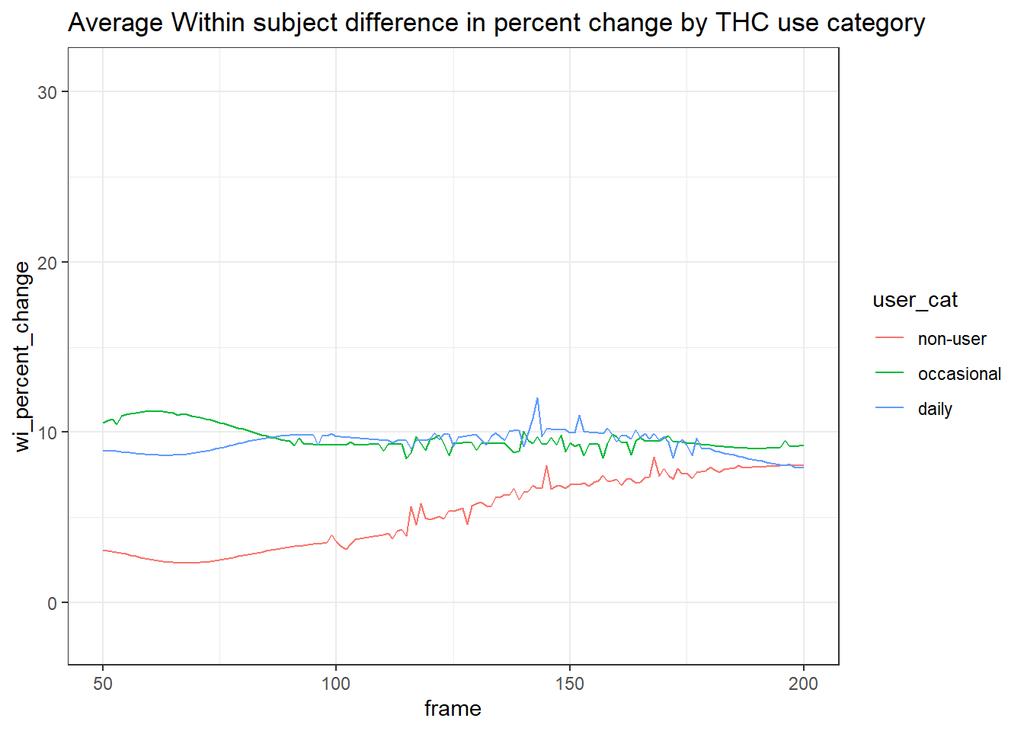

```r
## Within person plots
ggplot(mean_fxn.pt.l, aes(x=frame, y = wi_percent_change, group = user_cat, color = user_cat))+
  geom_line()+
  xlim(50, 200)+
  labs(title ="Average Within subject difference in percent change by THC use category")+
  theme_bw()
```

```r
## Mean function Spike in Occassional user group
mean_fxn.pt[mean_fxn.pt$Group.1 == "occasional", 113:119]
```

```
##   wiPctChg.112 wiPctChg.113 wiPctChg.114 wiPctChg.115 wiPctChg.116 wiPctChg.117
## 2     9.321055     9.323555     9.325425     8.454818     8.800647     9.756465
##   wiPctChg.118
## 2     9.337956
```

```r
right_0.pt.w[right_0.pt.w$user_cat == "occasional", 116:119]
```

```
##                    wiPctChg.114 wiPctChg.115 wiPctChg.116 wiPctChg.117
## 001-006_occasional   11.5010736   11.5256630   11.5441500   11.5567771
## 001-011_occasional   13.8610423   13.4068052   12.9843136   12.5971631
## 001-014_occasional   21.3107326   21.4515436   21.6131807   21.7968208
## 001-021_occasional   -1.1912416   -0.9231421   -0.6790802   -0.4625531
## 001-026_occasional    9.7779962    9.7134617    9.6452439    9.5739134
## 001-033_occasional   -4.5904810   -4.5847367   -4.5874266   -4.5993762
## 001-066_occasional   -2.9926603   -2.6954025   -2.4078270   -2.1356420
## 001-068_occasional   -2.3234722   -2.5620425   -2.8047079           NA
## 001-069_occasional   10.3751083   10.3261663   10.2674197   10.2007111
## 001-070_occasional   -6.3680231   -6.6819575   -6.9642840   -7.2115993
## 001-073_occasional    1.0988326    0.8742189    0.6410650    0.3974723
## 001-079_occasional    1.5458615    1.5596127    1.5732513    1.5872532
## 001-098_occasional   13.7185797   13.7309383   13.7531044   13.7858458
## 001-103_occasional   13.3247626   13.1186223   12.9151765   12.7150573
## 001-104_occasional   12.7854841   13.1440297   13.4777229   13.7848223
## 001-105_occasional    5.5596362    5.0371812    4.5128967    3.9884444
## 001-106_occasional   31.6685053   31.4176485   31.1680513   30.9234781
## 001-107_occasional   13.0855226   13.1838102   13.2833605   13.3842042
## 001-108_occasional    0.6176109    0.8447543    1.0849742    1.3358006
## 001-109_occasional  -15.7166154  -15.3591468  -15.0150126  -14.6856549
## 001-110_occasional   20.8014945   20.6608085   20.5292836   20.4062968
## 001-111_occasional   24.6366830   24.5955681           NA   24.5397456
## 001-112_occasional    5.4392987    5.2952310    5.1482113    5.0007441
## 001-113_occasional    4.3581125    4.6115089    4.8917672    5.1963956
## 001-114_occasional    8.3133753           NA    9.0936072    9.6649670
## 001-116_occasional    9.5616376   10.2337297   10.9367739   11.6657409
## 001-117_occasional   26.0633785   25.9994142   25.9175125   25.8186124
## 001-118_occasional   22.3015542   22.0631247   21.8292447   21.6023908
## 001-061_occasional   -3.1586454   -3.2525226   -3.3458427   -3.4373346
## 001-074_occasional   34.3975966           NA   34.2126412   33.9469985
```

```r
## Mean function Spike in Daily user group
mean_fxn.pt[mean_fxn.pt$Group.1 == "daily", 133:149]
```

```
##   wiPctChg.132 wiPctChg.133 wiPctChg.134 wiPctChg.135 wiPctChg.136 wiPctChg.137
## 3     9.277331     9.745381     9.979741     9.761392     9.535792     10.07879
##   wiPctChg.138 wiPctChg.139 wiPctChg.140 wiPctChg.141 wiPctChg.142 wiPctChg.143
## 3     10.10521     10.12753     9.170105     9.967127     10.84453     12.05176
##   wiPctChg.144 wiPctChg.145 wiPctChg.146 wiPctChg.147 wiPctChg.148
## 3     9.733335     10.18234     10.17635      10.1437     10.15056
```

```r
right_0.pt.w[right_0.pt.w$user_cat == "daily", 143:146]
```

```
##               wiPctChg.141 wiPctChg.142 wiPctChg.143 wiPctChg.144
## 001-002_daily           NA   14.7153791    14.601849    14.495408
## 001-008_daily   14.7396420   14.7359309    14.729108    14.719145
## 001-010_daily   11.4783127   11.7425889    12.013432    12.288979
## 001-012_daily   33.4153783   33.3457661    33.274294    33.200908
## 001-018_daily    0.7302098    0.8743156     1.019096     1.163107
## 001-022_daily   19.1083615   19.0395858    18.998221    18.982808
## 001-024_daily    3.7780247    3.7627633           NA     3.822039
## 001-027_daily   -1.7850082   -1.7402579    -1.684847    -1.620898
## 001-044_daily   10.2479799   10.1786281    10.105654    10.028880
## 001-056_daily    3.6104524    3.6402340     3.666943     3.690611
## 001-063_daily   20.4580365   20.7316590    20.963443           NA
## 001-064_daily    2.7132570           NA     3.009631     3.197956
## 001-067_daily   11.1802980   11.1078556    11.034733    10.960500
## 001-075_daily   15.0383830   15.2525116    15.432585    15.575752
## 001-081_daily   20.1667975   19.9577148    19.758334    19.568175
## 001-083_daily    6.5437739    6.7744270           NA     7.279460
## 001-085_daily    2.4370639    2.4914371           NA     2.661117
## 001-086_daily   15.4687276   15.3217226    15.147036    14.945924
## 001-088_daily   18.6395264   18.5982227    18.530299    18.439520
## 001-090_daily   12.8303747   13.4777605    14.106619    14.712315
## 001-091_daily    2.7300374    2.3344146     1.952296     1.587665
## 001-093_daily   10.2499191   10.0865217     9.897907     9.687709
## 001-094_daily  -11.5874056  -11.7885342           NA   -12.022410
## 001-096_daily   15.0428194   14.7835467    14.512852    14.232459
## 001-013_daily    1.9760770           NA     2.017467     2.002911
```

Jagged changes in the mean function lines seems to stem from missing data at those frames in the data set. The subjects per user-group is between 25 - 30, so missing data for one individual has a noticeable effect on mean function line.

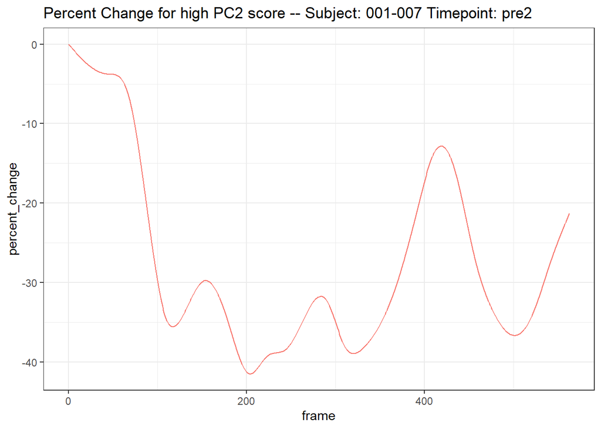

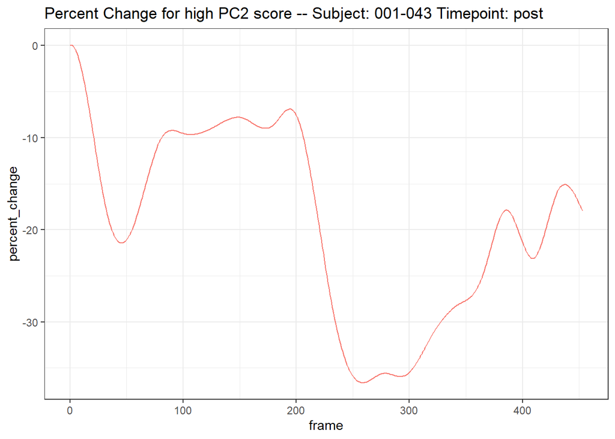

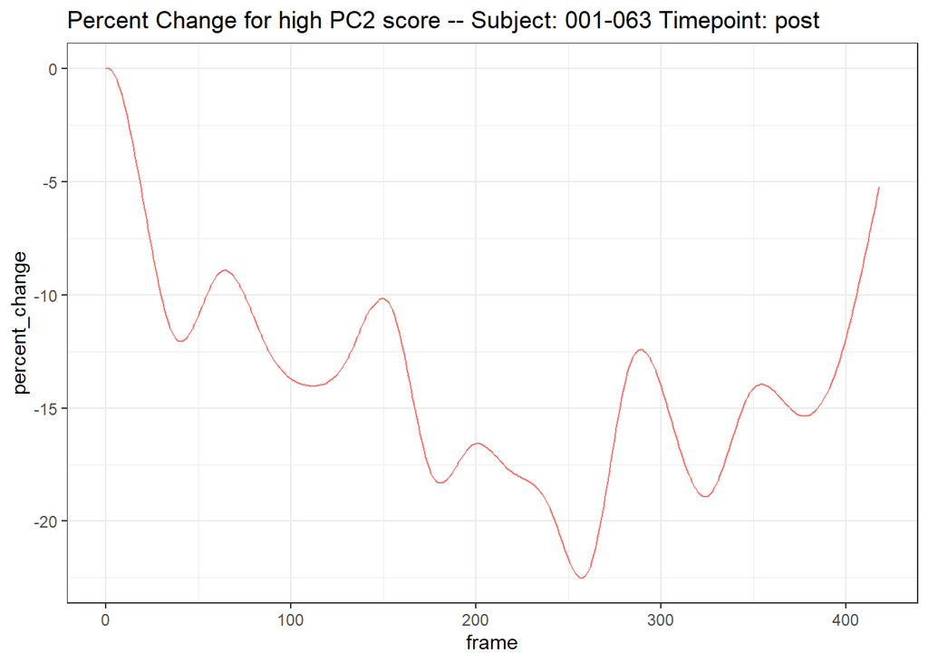

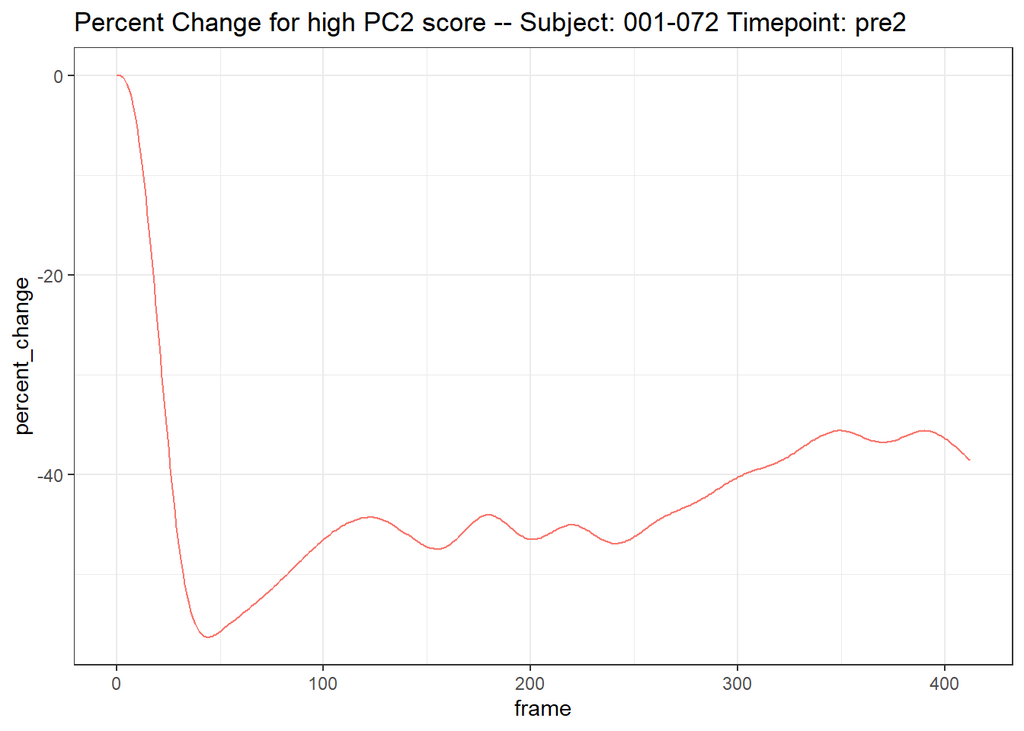

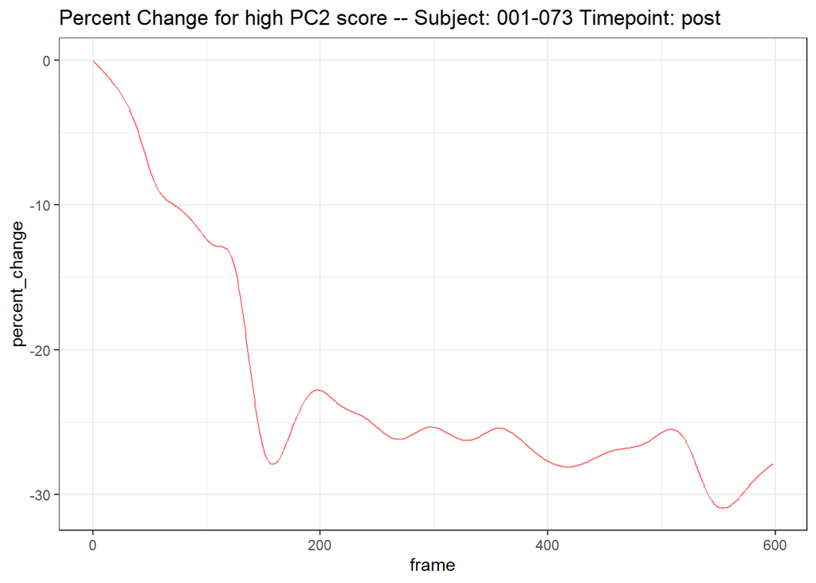

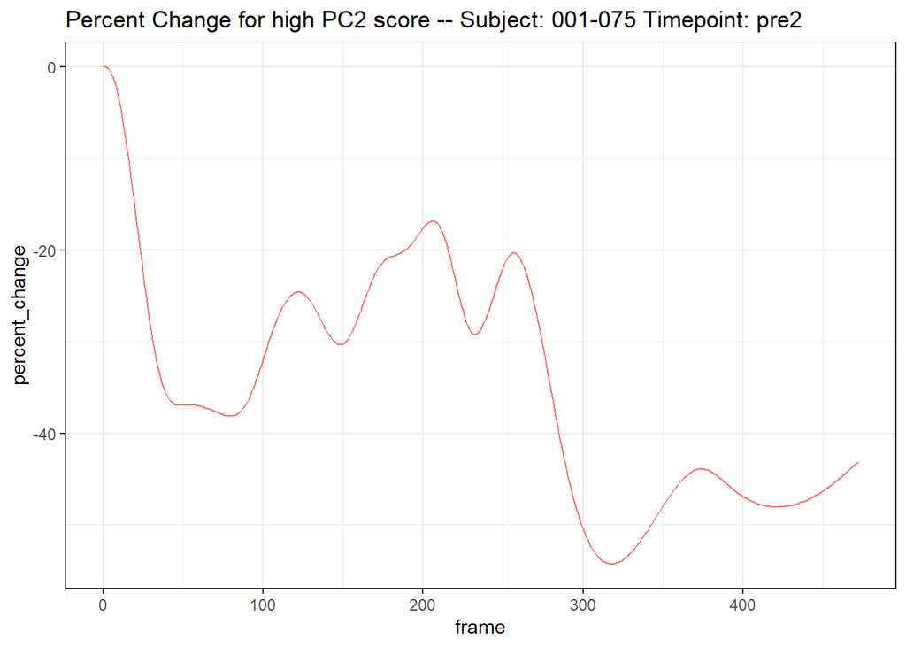

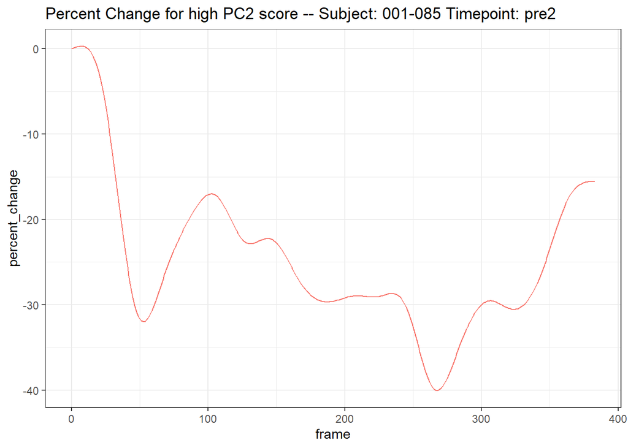

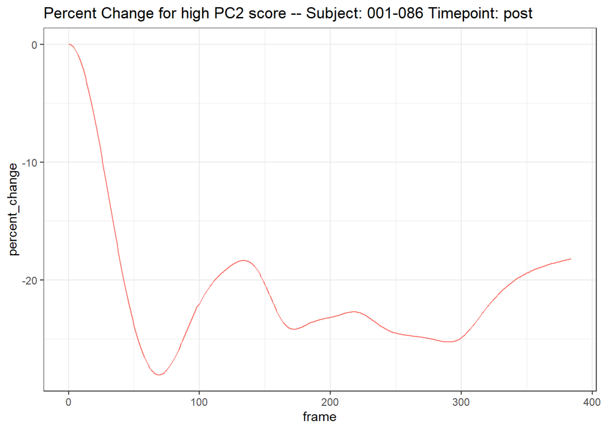

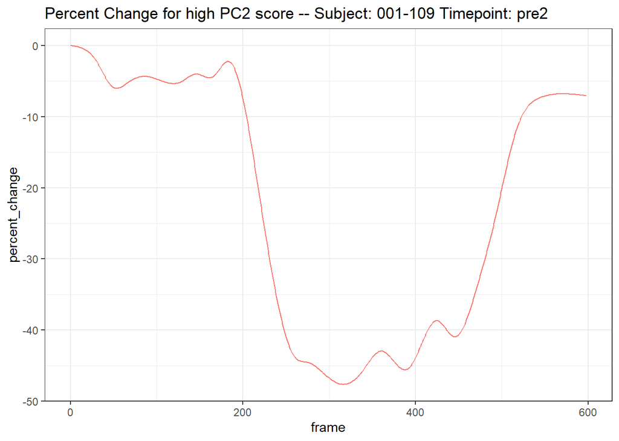

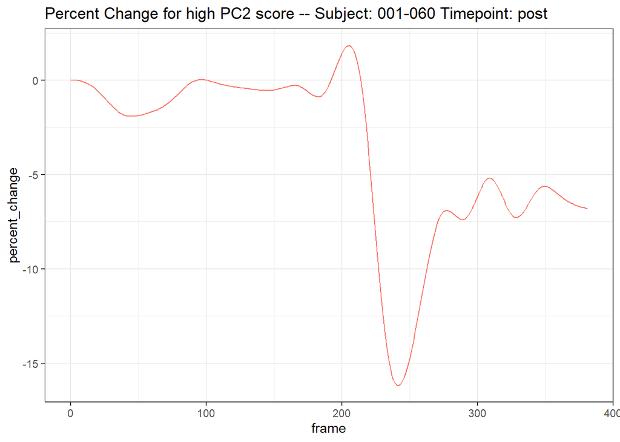

```r
right_scores <- right_0.fpca$scores
q.95 <- quantile(right_scores[, 2], p = 0.95)

highPC2 <- rownames(right_scores)[right_scores[, 2] > q.95]

highPC2.df <- data.frame(subject_id = substr(highPC2, 1, 7),
                         tp = substr(highPC2, 9,12))


for(i in 1:nrow(highPC2.df)){
  plot.df <- right_0.df[right_0.df$subject_id == highPC2.df$subject_id[i] & right_0.df$tp == highPC2.df$tp[i], ]
  print(ggplot(plot.df, aes(x=frame, y = percent_change, group = subject_id, color = subject_id))+
          geom_line(show.legend = FALSE)+
          labs(title = paste("Percent Change for high PC2 score --", "Subject:", highPC2.df$subject_id[i], "Timepoint:",                                      highPC2.df$tp[i]))+
          theme_bw())
}
```

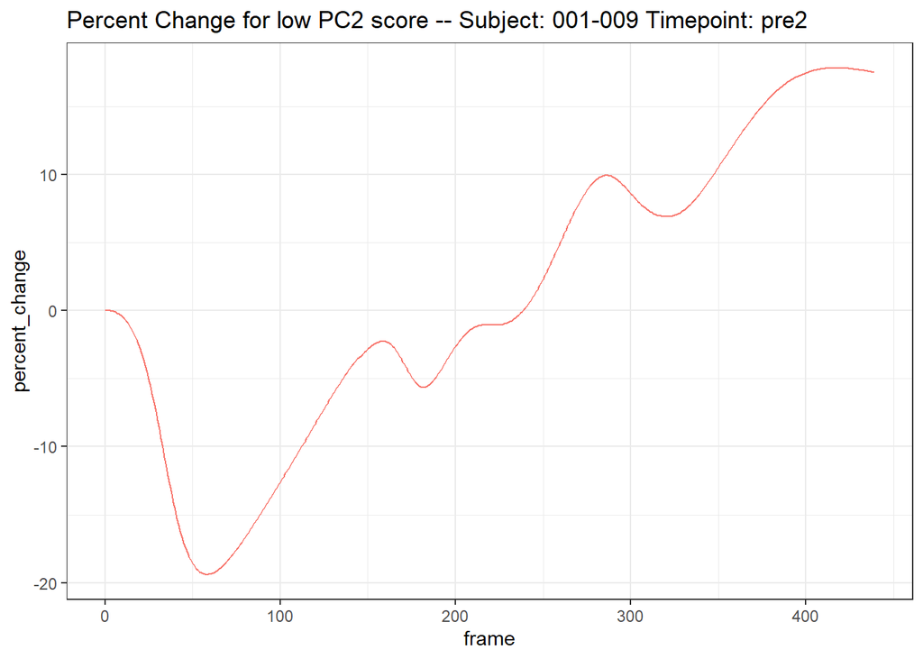

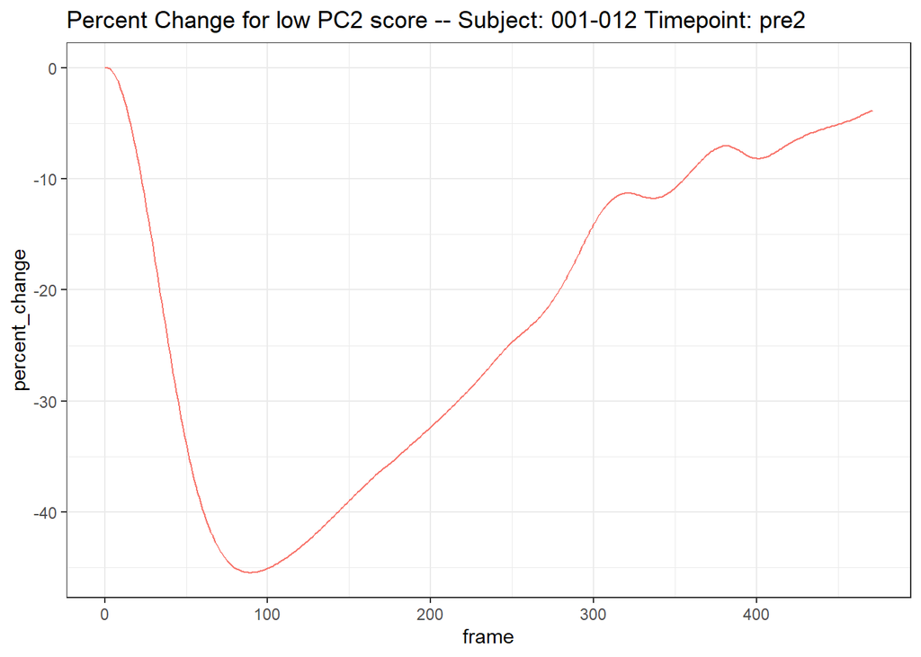

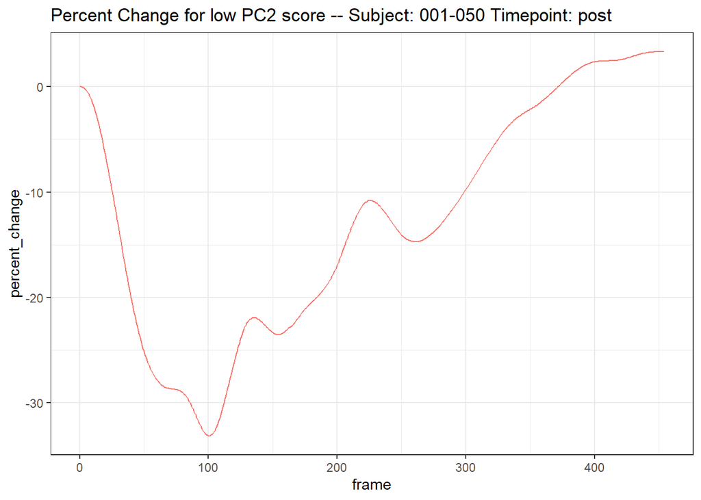

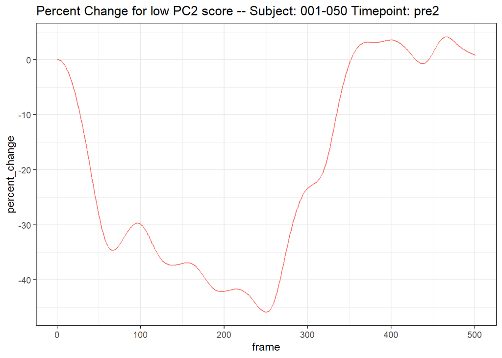

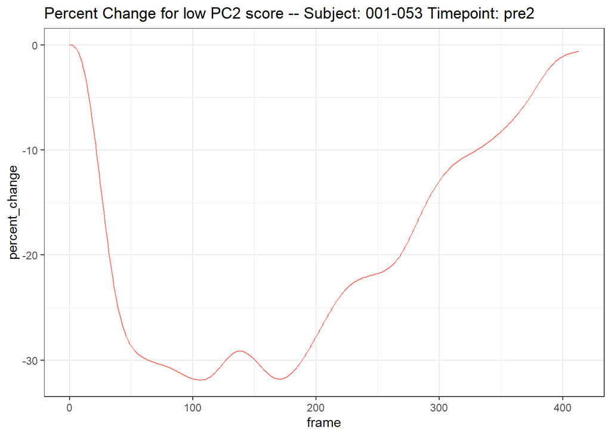

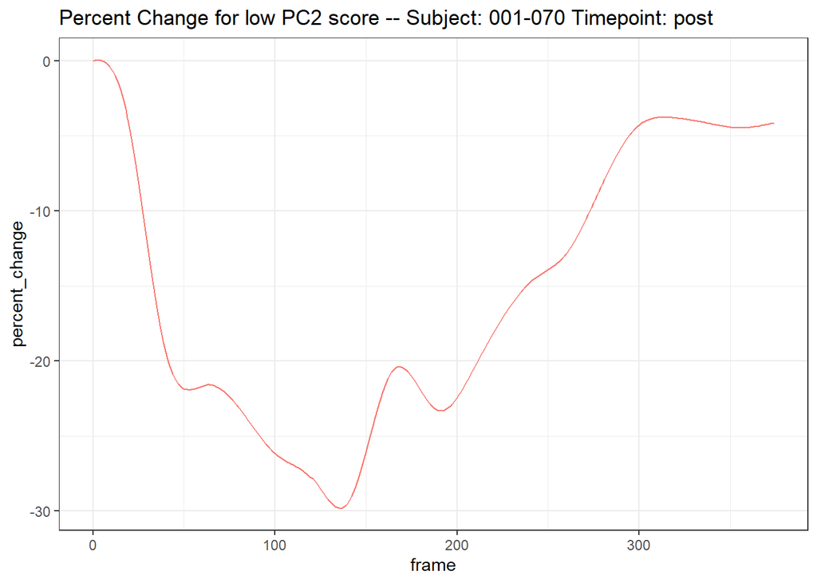

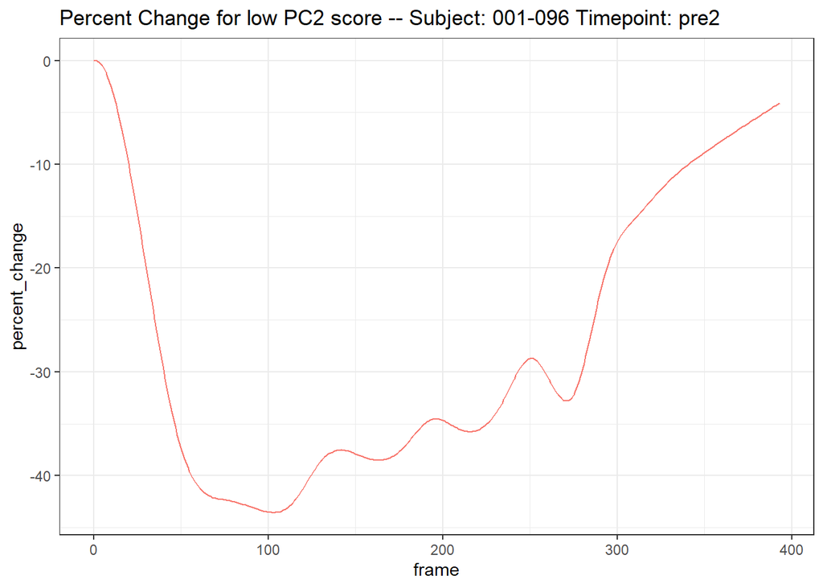

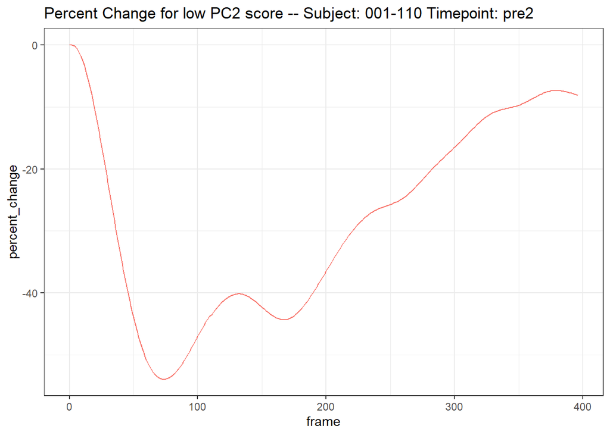

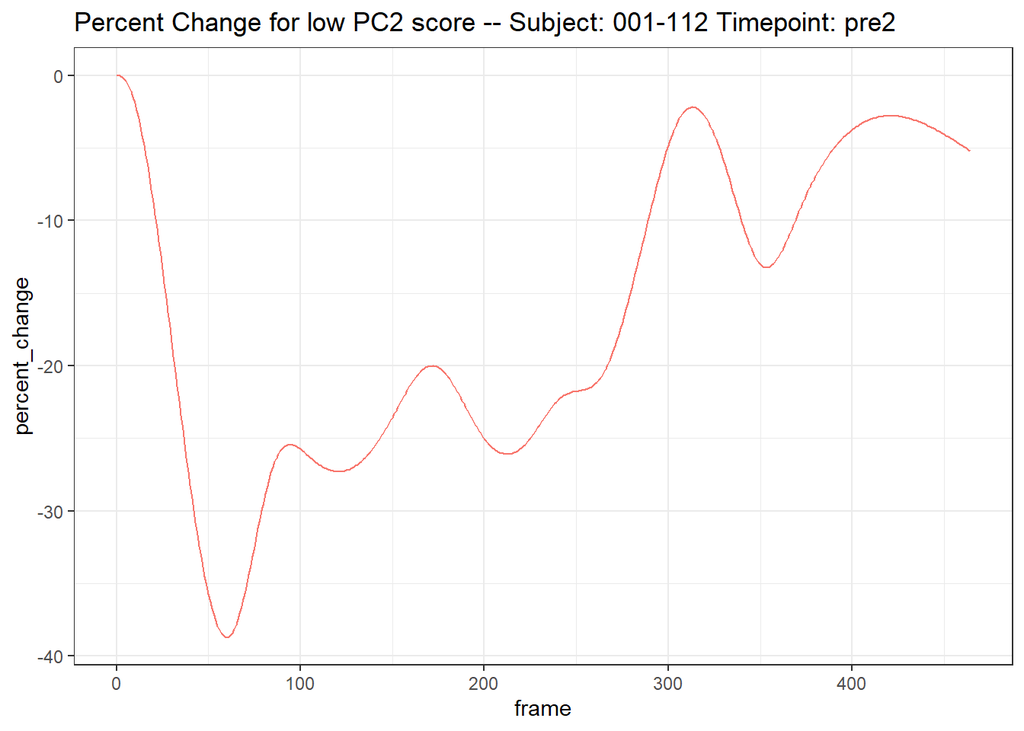

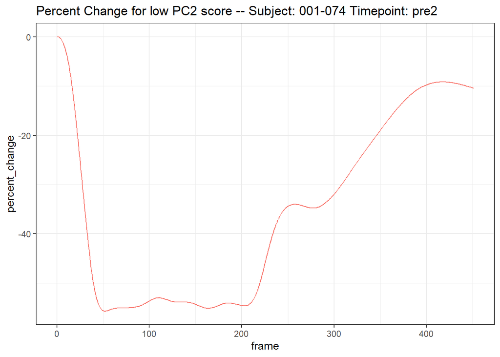

```r
q.05 <- quantile(right_scores[, 2], p = 0.05)

lowPC2 <- rownames(right_scores)[right_scores[, 2] < q.05]

lowPC2.df <- data.frame(subject_id = substr(lowPC2, 1, 7),
                         tp = substr(lowPC2, 9,12))


for(i in 1:nrow(lowPC2.df)){
  plot.df <- right_0.df[right_0.df$subject_id == lowPC2.df$subject_id[i] & right_0.df$tp == lowPC2.df$tp[i], ]
  print(ggplot(plot.df, aes(x=frame, y = percent_change, group = subject_id, color = subject_id))+
          geom_line(show.legend = FALSE)+
          labs(title = paste("Percent Change for low PC2 score --", "Subject:", lowPC2.df$subject_id[i], "Timepoint:",                                      lowPC2.df$tp[i]))+
          theme_bw())
}
```

### 8.0.1 Logistic Regression models to predict Smoker vs non-smoker. plot AUC

```r
right_scores <- as.data.frame(right_scores)
names(right_scores) <- c("PC1", "PC2", "PC3", "PC4")
right_scores$id <-  rownames(right_scores)
right_scores$subject_id <- substr(right_scores$id, 1, 7)
right_scores$tp <- substr(right_scores$id, 9, 12)

pt.scores <- merge(right_scores, pt.df,
                   by = c("subject_id", "tp"))

pt.scores$postConsumpTimeToTest[pt.scores$tp == "pre2"] <- 0

pt.scores$smoker <- ifelse(pt.scores$user_cat %in% c("daily", "occasional"),1, 0)

val.sample <- sample(unique(pt.scores$subject_id), size = round(length(unique(pt.scores$subject_id))*0.3, 0))
train.sample <- unique(pt.scores$subject_id[!(pt.scores$subject_id %in% val.sample)])

# prop.table(table(pt.scores$smoker[pt.scores$subject_id %in% val.sample])) #check distribution of smokers to non-smokers in validation sample

m1 <- glm(smoker ~ PC1 + PC2, family = "binomial", data = pt.scores[pt.scores$subject_id %in% train.sample, ])

pt.scores$pred <- predict(m1, pt.scores)

pt.scores.val <- pt.scores[pt.scores$subject_id %in% train.sample, ]

pt.scores.roc <- roc(response = pt.scores.val$smoker, predictor = pt.scores.val$pred)
```

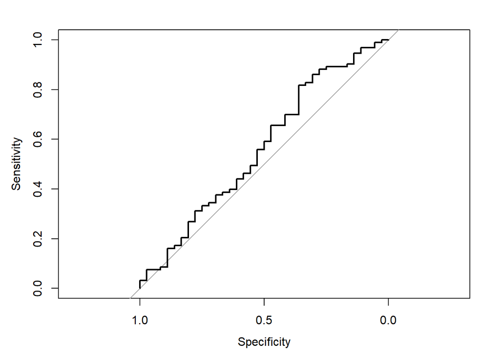

```r
plot.roc(pt.scores.roc)
```